# MIDUS 2 Models: Full-Time, Standard-Shift Sample

# About this script

**Primary, preregistered analysis (main text).** Full-time, standard-daytime-shift participants.

Fits Models 1a, 1a + weekend, 1b, 2a, and 2b (raw TV; preregistered), plus Model 2b with log1p TV (secondary; not preregistered). Run `M2_data_structuring.Rmd` first. Fitted models, LOO, and k-fold objects are cached in `model_fits_m2/fulltime_standard/`, so re-knitting reloads them instead of refitting.

Robustness checks (not preregistered): 10-fold cross-validation for the random-scale model comparisons, because many observations have Pareto k > 0.7 even after moment matching; and Model 2b refit with `mi()` to include days with sleep but missing TV.

Models with doubled iterations (bulk ESS < 1000 at 2000 iterations, per the prereg): `model_2b_log`, `model_2b_mi`.

# Packages, data, and helper functions

```r
library(dplyr)
library(brms)
```

```r
M2_sample <- readRDS("M2_analysis_data_fulltime_standard.rds")

model_output_dir <- "model_fits_m2/fulltime_standard"
dir.create(model_output_dir, showWarnings = FALSE, recursive = TRUE)

tag <- "fulltime_standard"

# Computes LOO once and caches it to disk
get_loo <- function(model, path) {
  if (file.exists(path)) {
    readRDS(path)
  } else {
    loo_result <- loo(model, moment_match = TRUE)
    saveRDS(loo_result, path)
    loo_result
  }
}

# kfold() runs refits through the future package, which by default
# refuses to pass objects over 500 MB (the fitted models are larger).
# Folds run one at a time in this session, so nothing is copied.
options(future.globals.maxSize = Inf)

# Computes 10-fold CV once and caches it to disk (refits are not saved,
# to keep disk use low)
get_kfold <- function(model, folds, path) {
  if (file.exists(path)) {
    readRDS(path)
  } else {
    kfold_result <- kfold(model, folds = folds, seed = 2026)
    saveRDS(kfold_result, path)
    kfold_result
  }
}

# Assigns K folds stratified by participant: each person's rows are
# shuffled and dealt across folds in turn, so their days land in different
# folds. Same algorithm as loo::kfold_split_stratified() in loo >= 2.9.0.
# Written out because loo 2.8.0 mishandles participants with a single row
# (sample(n) draws from 1:n), which silently un-stratifies the folds.
split_folds_by_id <- function(id, K = 10) {
  id <- as.integer(factor(id))
  row_order <- integer()
  for (person in seq_len(max(id))) {
    rows <- which(id == person)
    if (length(rows) > 1) rows <- sample(rows)
    row_order <- c(row_order, rows)
  }
  folds <- rep(NA_integer_, length(id))
  folds[row_order] <- rep(1:K, ceiling(length(id) / K))[seq_along(id)]
  folds
}

# Prereg convergence criteria: R-hat < 1.01, bulk and tail ESS > 1000,
# and 0 divergent transitions (population-level, SD, and correlation
# parameters; bsp_ and sigma_ cover the mi() model)
check_convergence <- function(fit) {
  draws_summary <- posterior::summarise_draws(
    as_draws_df(fit, variable = "^(b_|bsp_|sd_|cor_|sigma$|sigma_)", regex = TRUE),
    "rhat", "ess_bulk", "ess_tail"
  )

  tibble(
    max_rhat = max(draws_summary$rhat, na.rm = TRUE),
    min_bulk_ess = min(draws_summary$ess_bulk, na.rm = TRUE),
    min_tail_ess = min(draws_summary$ess_tail, na.rm = TRUE),
    divergent = sum(nuts_params(fit, pars = "divergent__")$Value)
  ) %>%
    mutate(
      meets_prereg = max_rhat < 1.01 & min_bulk_ess > 1000 &
        min_tail_ess > 1000 & divergent == 0
    )
}

# Prereg assumption check: Q-Q plot of level-1 residuals
check_residual_normality <- function(fit, label) {
  resid_est <- residuals(
    fit,
    method = "posterior_predict"
  )[, "Estimate"]

  qqnorm(
    resid_est,
    main = paste0(label, ": Level-1 residual Q-Q plot")
  )

  qqline(resid_est)
}
```

# Descriptive statistics

Sleep, TV, and weekend are summarized at the diary-day level; age and sex at the participant level.

```r
# Outcome and TV predictors (diary-day level)
M2_sample %>%
  summarise(
    sleep_mean = mean(sleep_next_night_minutes, na.rm = TRUE),
    sleep_sd = sd(sleep_next_night_minutes, na.rm = TRUE),
    sleep_min = min(sleep_next_night_minutes, na.rm = TRUE),
    sleep_max = max(sleep_next_night_minutes, na.rm = TRUE),
    sleep_missing = sum(is.na(sleep_next_night_minutes)),

    tv_mean = mean(tv_duration_minutes, na.rm = TRUE),
    tv_sd = sd(tv_duration_minutes, na.rm = TRUE),
    tv_min = min(tv_duration_minutes, na.rm = TRUE),
    tv_max = max(tv_duration_minutes, na.rm = TRUE),
    tv_missing = sum(is.na(tv_duration_minutes)),

    tv_log_mean = mean(tv_duration_minutes_log, na.rm = TRUE),
    tv_log_sd = sd(tv_duration_minutes_log, na.rm = TRUE),
    tv_log_missing = sum(is.na(tv_duration_minutes_log))
  ) %>%
  as.data.frame()
```

```
##   sleep_mean sleep_sd sleep_min sleep_max sleep_missing  tv_mean    tv_sd
## 1   425.7708 77.81981         0       960           216 90.59982 81.89248
##   tv_min tv_max tv_missing tv_log_mean tv_log_sd tv_log_missing
## 1      0    720        174    3.715848  1.782674            174
```

```r
# Weekend (diary-day level)
M2_sample %>%
  count(weekend)
```

```
## # A tibble: 2 × 2
##   weekend     n
##     <int> <int>
## 1       0  3283
## 2       1  1309
```

```r
# Age (participant level)
M2_sample %>%
  distinct(id, age) %>%
  summarise(
    age_mean = mean(age, na.rm = TRUE),
    age_sd = sd(age, na.rm = TRUE),
    age_min = min(age, na.rm = TRUE),
    age_max = max(age, na.rm = TRUE),
    age_missing = sum(is.na(age))
  )
```

```
## # A tibble: 1 × 5
##   age_mean age_sd age_min age_max age_missing
##      <dbl>  <dbl>   <dbl>   <dbl>       <int>
## 1     49.7   8.22      34      78           0
```

```r
# Sex (participant level; 0 = male, 1 = female)
M2_sample %>%
  distinct(id, sex) %>%
  count(sex)
```

```
## # A tibble: 2 × 2
##     sex     n
##   <dbl> <int>
## 1     0   344
## 2     1   312
```

# Sample characteristics

```r
# Analytic sample
M2_sample %>%
  summarise(
    total_rows = n(),
    participants = n_distinct(id),
    missing_next_sleep = sum(is.na(sleep_next_night_minutes)),
    usable_for_model = sum(!is.na(sleep_next_night_minutes)),
    usable_participants = n_distinct(
      id[!is.na(sleep_next_night_minutes)]
    )
  ) %>%
  as.data.frame()
```

```
##   total_rows participants missing_next_sleep usable_for_model
## 1       4592          656                216             4376
##   usable_participants
## 1                 656
```

```r
# Employment / shift (confirms the sample definition)
M2_sample %>%
  distinct(id, is_fulltime, is_standard_shift) %>%
  summarise(
    percent_fulltime = mean(is_fulltime == 1) * 100,
    percent_standard_shift = mean(is_standard_shift == 1) * 100
  )
```

```
## # A tibble: 1 × 2
##   percent_fulltime percent_standard_shift
##              <dbl>                  <dbl>
## 1              100                    100
```

```r
# Health conditions (participant level)
M2_sample %>%
  distinct(id, head_injury, neurological_disorder, chronic_sleep_problem) %>%
  summarise(
    n = n(),
    head_injury_n = sum(head_injury == 1, na.rm = TRUE),
    head_injury_percent = mean(head_injury == 1, na.rm = TRUE) * 100,
    neurological_disorder_n = sum(neurological_disorder == 1, na.rm = TRUE),
    neurological_disorder_percent = mean(neurological_disorder == 1, na.rm = TRUE) * 100,
    chronic_sleep_problem_n = sum(chronic_sleep_problem == 1, na.rm = TRUE),
    chronic_sleep_problem_percent = mean(chronic_sleep_problem == 1, na.rm = TRUE) * 100
  ) %>%
  as.data.frame()
```

```
##     n head_injury_n head_injury_percent neurological_disorder_n
## 1 656            14            2.137405                      26
##   neurological_disorder_percent chronic_sleep_problem_n
## 1                             4                      48
##   chronic_sleep_problem_percent
## 1                      7.667732
```

```r
# Family structure
M2_sample %>%
  distinct(id, M2FAMNUM) %>%
  count(M2FAMNUM, name = "family_size") %>%
  summarise(
    n_families = n(),
    n_singleton_families = sum(family_size == 1),
    n_multi_member_families = sum(family_size > 1),
    max_family_size = max(family_size)
  )
```

```
## # A tibble: 1 × 4
##   n_families n_singleton_families n_multi_member_families max_family_size
##        <int>                <int>                   <int>           <int>
## 1        590                  530                      60               5
```

```r
# Diary compliance: days with an observed next-night sleep report
M2_sample %>%
  group_by(id) %>%
  summarise(diary_days = sum(!is.na(sleep_next_night_minutes))) %>%
  summarise(
    mean_diary_days = mean(diary_days),
    median_diary_days = median(diary_days),
    min_diary_days = min(diary_days),
    max_diary_days = max(diary_days)
  )
```

```
## # A tibble: 1 × 4
##   mean_diary_days median_diary_days min_diary_days max_diary_days
##             <dbl>             <dbl>          <int>          <int>
## 1            6.67                 7              3              7
```

# Table 1 descriptives

Values for the manuscript’s descriptive table. Printed as data frames so they are not rounded.

```r
# Participant level: age, sex, and work schedule during the diary week
# (work defines the full-time, standard-shift sample)
M2_sample %>%
  distinct(id, age, sex, days_worked, total_work_hours) %>%
  summarise(
    participants = n(),
    age_mean = mean(age, na.rm = TRUE),
    age_sd = sd(age, na.rm = TRUE),
    n_female = sum(sex == 1, na.rm = TRUE),
    percent_female = mean(sex == 1, na.rm = TRUE) * 100,
    days_worked_mean = mean(days_worked, na.rm = TRUE),
    days_worked_sd = sd(days_worked, na.rm = TRUE),
    work_hours_mean = mean(total_work_hours, na.rm = TRUE),
    work_hours_sd = sd(total_work_hours, na.rm = TRUE)
  ) %>%
  as.data.frame()
```

```
##   participants age_mean   age_sd n_female percent_female days_worked_mean
## 1          656 49.67226 8.220115      312       47.56098         6.126524
##   days_worked_sd work_hours_mean work_hours_sd
## 1       1.088804        51.21504      10.23853
```

```r
# Diary-day level percentages
M2_sample %>%
  summarise(
    rows = n(),
    n_weekend = sum(weekend == 1, na.rm = TRUE),
    percent_weekend = mean(weekend == 1, na.rm = TRUE) * 100,
    n_tv_reported = sum(!is.na(tv_duration_minutes)),
    n_no_tv_days = sum(tv_duration_minutes == 0, na.rm = TRUE),
    percent_no_tv_days = mean(tv_duration_minutes == 0, na.rm = TRUE) * 100
  ) %>%
  as.data.frame()
```

```
##   rows n_weekend percent_weekend n_tv_reported n_no_tv_days percent_no_tv_days
## 1 4592      1309         28.5061          4418          724           16.38751
```

```r
# Participants who watched TV on at least one diary day
M2_sample %>%
  group_by(id) %>%
  summarise(any_tv = any(tv_duration_minutes > 0, na.rm = TRUE)) %>%
  summarise(
    n_any_tv = sum(any_tv),
    percent_any_tv = mean(any_tv) * 100
  ) %>%
  as.data.frame()
```

```
##   n_any_tv percent_any_tv
## 1      643       98.01829
```

```r
# Sleep and TV: overall M, SD, and median, plus between-person SD
# (SD of person means) and within-person SD (SD of deviations from
# each person's own mean)
describe_levels <- function(data, variable) {
  data %>%
    filter(!is.na({{ variable }})) %>%
    group_by(id) %>%
    mutate(
      person_mean = mean({{ variable }}),
      deviation = {{ variable }} - person_mean
    ) %>%
    ungroup() %>%
    summarise(
      n = n(),
      mean = mean({{ variable }}),
      sd = sd({{ variable }}),
      median = median({{ variable }}),
      between_person_sd = sd(person_mean[!duplicated(id)]),
      within_person_sd = sd(deviation)
    )
}

bind_rows(
  sleep_next_night_minutes = describe_levels(M2_sample, sleep_next_night_minutes),
  tv_duration_minutes = describe_levels(M2_sample, tv_duration_minutes),
  .id = "variable"
) %>%
  as.data.frame()
```

```
##                   variable    n      mean       sd median between_person_sd
## 1 sleep_next_night_minutes 4376 425.77080 77.81981    420          49.80965
## 2      tv_duration_minutes 4418  90.59982 81.89248     60          57.15899
##   within_person_sd
## 1         60.04687
## 2         58.61164
```

```r
# Complete TV-sleep pairs per participant (level-1 sample for Model 2b)
M2_sample %>%
  filter(!is.na(tv_duration_minutes), !is.na(sleep_next_night_minutes)) %>%
  count(id, name = "pairs") %>%
  summarise(
    total_pairs = sum(pairs),
    participants = n(),
    mean_pairs = mean(pairs),
    median_pairs = median(pairs),
    min_pairs = min(pairs),
    max_pairs = max(pairs)
  ) %>%
  as.data.frame()
```

```
##   total_pairs participants mean_pairs median_pairs min_pairs max_pairs
## 1        4229          656   6.446646            7         1         7
```

# Model 1a: unconditional means model

```r
message("Fitting model_1a (", tag, ")")
```

```
## Fitting model_1a (fulltime_standard)
```

```r
model_1a <- brm(
  sleep_next_night_minutes ~ 1 + (1 | id),
  data = M2_sample,
  family = gaussian(),
  chains = 4,
  iter = 2000,
  warmup = 1000,
  seed = 2026,
  save_pars = save_pars(all = TRUE),
  file = file.path(model_output_dir, paste0("model_1a_", tag, "_m2")),
  file_refit = "never"
)

summary(model_1a, prob = 0.9)
```

```
##  Family: gaussian
##   Links: mu = identity; sigma = identity
## Formula: sleep_next_night_minutes ~ 1 + (1 | id)
##    Data: M2_sample (Number of observations: 4376)
##   Draws: 4 chains, each with iter = 2000; warmup = 1000; thin = 1;
##          total post-warmup draws = 4000
##
## Multilevel Hyperparameters:
## ~id (Number of levels: 656)
##               Estimate Est.Error l-90% CI u-90% CI Rhat Bulk_ESS Tail_ESS
## sd(Intercept)    42.78      1.63    40.07    45.46 1.00     1390     2156
##
## Regression Coefficients:
##           Estimate Est.Error l-90% CI u-90% CI Rhat Bulk_ESS Tail_ESS
## Intercept   425.33      1.92   422.25   428.53 1.00     1352     2126
##
## Further Distributional Parameters:
##       Estimate Est.Error l-90% CI u-90% CI Rhat Bulk_ESS Tail_ESS
## sigma    65.18      0.76    63.93    66.42 1.00     4636     2780
##
## Draws were sampled using sampling(NUTS). For each parameter, Bulk_ESS
## and Tail_ESS are effective sample size measures, and Rhat is the potential
## scale reduction factor on split chains (at convergence, Rhat = 1).
```

```r
# ICC
variance_components_1a <- VarCorr(model_1a)

between_person_var_1a <- variance_components_1a$id$sd[1, "Estimate"]^2
residual_var_1a <- variance_components_1a$residual__$sd[1, "Estimate"]^2
icc_1a <- between_person_var_1a /
  (between_person_var_1a + residual_var_1a)

fixef(model_1a, probs = c(0.05, 0.95))
```

```
##           Estimate Est.Error      Q5      Q95
## Intercept 425.3286  1.919358 422.246 428.5334
```

```r
between_person_var_1a
```

```
## [1] 1830.116
```

```r
residual_var_1a
```

```
## [1] 4247.967
```

```r
icc_1a
```

```
## [1] 0.3011009
```

# Model 1a with weekend control

```r
message("Fitting model_weekend (", tag, ")")
```

```
## Fitting model_weekend (fulltime_standard)
```

```r
model_weekend <- brm(
  sleep_next_night_minutes ~ 1 + weekend + (1 | id),
  data = M2_sample,
  family = gaussian(),
  chains = 4,
  iter = 2000,
  warmup = 1000,
  seed = 2026,
  save_pars = save_pars(all = TRUE),
  file = file.path(model_output_dir, paste0("model_weekend_", tag, "_m2")),
  file_refit = "never"
)

summary(model_weekend, prob = 0.9)
```

```
##  Family: gaussian
##   Links: mu = identity; sigma = identity
## Formula: sleep_next_night_minutes ~ 1 + weekend + (1 | id)
##    Data: M2_sample (Number of observations: 4376)
##   Draws: 4 chains, each with iter = 2000; warmup = 1000; thin = 1;
##          total post-warmup draws = 4000
##
## Multilevel Hyperparameters:
## ~id (Number of levels: 656)
##               Estimate Est.Error l-90% CI u-90% CI Rhat Bulk_ESS Tail_ESS
## sd(Intercept)    42.92      1.62    40.31    45.70 1.00     1138     2284
##
## Regression Coefficients:
##           Estimate Est.Error l-90% CI u-90% CI Rhat Bulk_ESS Tail_ESS
## Intercept   421.62      2.05   418.33   425.04 1.00     1135     2162
## weekend      13.01      2.14     9.50    16.43 1.00     5743     2442
##
## Further Distributional Parameters:
##       Estimate Est.Error l-90% CI u-90% CI Rhat Bulk_ESS Tail_ESS
## sigma    64.83      0.74    63.61    66.07 1.00     4318     3074
##
## Draws were sampled using sampling(NUTS). For each parameter, Bulk_ESS
## and Tail_ESS are effective sample size measures, and Rhat is the potential
## scale reduction factor on split chains (at convergence, Rhat = 1).
```

```r
# ICC
variance_components_weekend <- VarCorr(model_weekend)

between_person_var_weekend <- variance_components_weekend$id$sd[1, "Estimate"]^2
residual_var_weekend <- variance_components_weekend$residual__$sd[1, "Estimate"]^2
icc_weekend <- between_person_var_weekend /
  (between_person_var_weekend + residual_var_weekend)

fixef(model_weekend, probs = c(0.05, 0.95))
```

```
##            Estimate Est.Error         Q5       Q95
## Intercept 421.62458  2.046266 418.332362 425.03556
## weekend    13.01343  2.137627   9.498467  16.43427
```

```r
between_person_var_weekend
```

```
## [1] 1841.878
```

```r
residual_var_weekend
```

```
## [1] 4203.539
```

```r
icc_weekend
```

```
## [1] 0.3046735
```

# Comparing Model 1a and the weekend-control model

The weekend indicator is retained in all later models regardless of this comparison (prereg).

```r
loo_1a <- get_loo(model_1a, file.path(model_output_dir, paste0("loo_1a_", tag, "_m2.rds")))
loo_weekend <- get_loo(model_weekend, file.path(model_output_dir, paste0("loo_weekend_", tag, "_m2.rds")))

loo_compare(list(model_1a = loo_1a, model_weekend = loo_weekend))
```

```
##               elpd_diff se_diff
## model_weekend   0.0       0.0
## model_1a      -21.6       6.9
```

# Model 1b: person-specific residual variance (random scale)

`sigma ~ 1 + (1 | q | id)` lets the residual variance differ by person; the shared `q` tag estimates the intercept-scale correlation.

```r
message("Fitting model_1b (", tag, ")")
```

```
## Fitting model_1b (fulltime_standard)
```

```r
model_1b <- brm(
  bf(
    sleep_next_night_minutes ~ 1 + weekend + (1 | q | id),
    sigma ~ 1 + (1 | q | id)
  ),
  data = M2_sample,
  family = gaussian(),
  chains = 4,
  iter = 2000,
  warmup = 1000,
  seed = 2026,
  save_pars = save_pars(all = TRUE),
  file = file.path(model_output_dir, paste0("model_1b_", tag, "_m2")),
  file_refit = "never"
)

summary(model_1b, prob = 0.9)
```

```
##  Family: gaussian
##   Links: mu = identity; sigma = log
## Formula: sleep_next_night_minutes ~ 1 + weekend + (1 | q | id)
##          sigma ~ 1 + (1 | q | id)
##    Data: M2_sample (Number of observations: 4376)
##   Draws: 4 chains, each with iter = 2000; warmup = 1000; thin = 1;
##          total post-warmup draws = 4000
##
## Multilevel Hyperparameters:
## ~id (Number of levels: 656)
##                                Estimate Est.Error l-90% CI u-90% CI Rhat
## sd(Intercept)                     41.12      1.60    38.53    43.81 1.00
## sd(sigma_Intercept)                0.49      0.02     0.45     0.53 1.00
## cor(Intercept,sigma_Intercept)    -0.33      0.05    -0.41    -0.24 1.00
##                                Bulk_ESS Tail_ESS
## sd(Intercept)                      1281     2199
## sd(sigma_Intercept)                1278     1968
## cor(Intercept,sigma_Intercept)     1110     2100
##
## Regression Coefficients:
##                 Estimate Est.Error l-90% CI u-90% CI Rhat Bulk_ESS Tail_ESS
## Intercept         422.42      1.93   419.23   425.57 1.00     1495     2214
## sigma_Intercept     3.96      0.02     3.92     4.00 1.00     1970     2698
## weekend            11.38      1.68     8.64    14.17 1.00     4552     3249
##
## Draws were sampled using sampling(NUTS). For each parameter, Bulk_ESS
## and Tail_ESS are effective sample size measures, and Rhat is the potential
## scale reduction factor on split chains (at convergence, Rhat = 1).
```

# Comparing the weekend-control model and Model 1b

The better-fitting residual structure is carried forward (prereg).

```r
loo_1b <- get_loo(model_1b, file.path(model_output_dir, paste0("loo_1b_", tag, "_m2.rds")))

loo_compare(list(model_weekend = loo_weekend, model_1b = loo_1b))
```

```
##               elpd_diff se_diff
## model_1b         0.0       0.0
## model_weekend -554.2      55.2
```

# Model 2a: age and sex

Age is mean-centered at the participant level.

```r
age_mean <- M2_sample %>%
  distinct(id, age) %>%
  summarise(m = mean(age, na.rm = TRUE)) %>%
  pull(m)

M2_sample <- M2_sample %>%
  mutate(age_centered = age - age_mean)
```

```r
message("Fitting model_2a (", tag, ")")
```

```
## Fitting model_2a (fulltime_standard)
```

```r
model_2a <- brm(
  bf(
    sleep_next_night_minutes ~
      1 + weekend + age_centered + sex +
      (1 | q | id),

    sigma ~ 1 + (1 | q | id)
  ),
  data = M2_sample,
  family = gaussian(),
  chains = 4,
  iter = 2000,
  warmup = 1000,
  seed = 2026,
  save_pars = save_pars(all = TRUE),
  file = file.path(
    model_output_dir,
    paste0("model_2a_", tag, "_m2")
  ),
  file_refit = "never"
)

summary(model_2a, prob = 0.9)
```

```
##  Family: gaussian
##   Links: mu = identity; sigma = log
## Formula: sleep_next_night_minutes ~ 1 + weekend + age_centered + sex + (1 | q | id)
##          sigma ~ 1 + (1 | q | id)
##    Data: M2_sample (Number of observations: 4376)
##   Draws: 4 chains, each with iter = 2000; warmup = 1000; thin = 1;
##          total post-warmup draws = 4000
##
## Multilevel Hyperparameters:
## ~id (Number of levels: 656)
##                                Estimate Est.Error l-90% CI u-90% CI Rhat
## sd(Intercept)                     41.08      1.55    38.57    43.72 1.00
## sd(sigma_Intercept)                0.49      0.02     0.46     0.53 1.00
## cor(Intercept,sigma_Intercept)    -0.36      0.06    -0.45    -0.27 1.00
##                                Bulk_ESS Tail_ESS
## sd(Intercept)                      1523     2428
## sd(sigma_Intercept)                1504     2290
## cor(Intercept,sigma_Intercept)     1074     2012
##
## Regression Coefficients:
##                 Estimate Est.Error l-90% CI u-90% CI Rhat Bulk_ESS Tail_ESS
## Intercept         417.57      2.62   413.18   421.80 1.00     1304     1908
## sigma_Intercept     3.96      0.02     3.93     4.00 1.00     2052     2583
## weekend            11.44      1.64     8.67    14.11 1.00     5271     2998
## age_centered       -0.12      0.22    -0.48     0.22 1.00     1347     1948
## sex                10.11      3.55     4.37    15.99 1.00     1429     2327
##
## Draws were sampled using sampling(NUTS). For each parameter, Bulk_ESS
## and Tail_ESS are effective sample size measures, and Rhat is the potential
## scale reduction factor on split chains (at convergence, Rhat = 1).
```

# Model 2b: within- and between-person TV (raw minutes; preregistered)

TV is person-mean centered (`tv_within`), and each person’s mean is grand-mean centered across participants (`tv_person_mean`).

```r
M2_sample <- M2_sample %>%
  group_by(id) %>%
  mutate(
    tv_person_mean_raw = mean(tv_duration_minutes, na.rm = TRUE),
    tv_within = tv_duration_minutes - tv_person_mean_raw
  ) %>%
  ungroup()

# Equally weighted mean of participants' TV means
tv_grand_mean <- M2_sample %>%
  distinct(id, tv_person_mean_raw) %>%
  summarise(
    grand_mean = mean(tv_person_mean_raw, na.rm = TRUE)
  ) %>%
  pull(grand_mean)

M2_sample <- M2_sample %>%
  mutate(
    tv_person_mean = tv_person_mean_raw - tv_grand_mean
  )

# QC: centered person means should average ~0
tv_grand_mean
```

```
## [1] 90.19505
```

```r
M2_sample %>%
  distinct(id, tv_person_mean_raw, tv_person_mean) %>%
  summarise(
    participants = n(),
    grand_mean_raw = mean(tv_person_mean_raw),
    grand_mean_centered = mean(tv_person_mean)
  )
```

```
## # A tibble: 1 × 3
##   participants grand_mean_raw grand_mean_centered
##          <int>          <dbl>               <dbl>
## 1          656           90.2            5.17e-15
```

```r
message("Fitting model_2b (", tag, ")")
```

```
## Fitting model_2b (fulltime_standard)
```

```r
model_2b <- brm(
  bf(
    sleep_next_night_minutes ~
      1 + weekend + age_centered + sex +
      tv_within + tv_person_mean +
      (1 | q | id),

    sigma ~ 1 + (1 | q | id)
  ),
  data = M2_sample,
  family = gaussian(),
  chains = 4,
  iter = 2000,
  warmup = 1000,
  seed = 2026,
  save_pars = save_pars(all = TRUE),
  file = file.path(
    model_output_dir,
    paste0("model_2b_", tag, "_m2")
  ),
  file_refit = "never"
)

summary(model_2b, prob = 0.9)
```

```
##  Family: gaussian
##   Links: mu = identity; sigma = log
## Formula: sleep_next_night_minutes ~ 1 + weekend + age_centered + sex + tv_within + tv_person_mean + (1 | q | id)
##          sigma ~ 1 + (1 | q | id)
##    Data: M2_sample (Number of observations: 4229)
##   Draws: 4 chains, each with iter = 2000; warmup = 1000; thin = 1;
##          total post-warmup draws = 4000
##
## Multilevel Hyperparameters:
## ~id (Number of levels: 656)
##                                Estimate Est.Error l-90% CI u-90% CI Rhat
## sd(Intercept)                     41.35      1.63    38.75    44.07 1.00
## sd(sigma_Intercept)                0.49      0.02     0.46     0.53 1.00
## cor(Intercept,sigma_Intercept)    -0.32      0.06    -0.41    -0.23 1.00
##                                Bulk_ESS Tail_ESS
## sd(Intercept)                      1218     1942
## sd(sigma_Intercept)                1460     2468
## cor(Intercept,sigma_Intercept)     1042     2236
##
## Regression Coefficients:
##                 Estimate Est.Error l-90% CI u-90% CI Rhat Bulk_ESS Tail_ESS
## Intercept         418.11      2.69   413.68   422.47 1.00     1234     1652
## sigma_Intercept     3.95      0.02     3.92     3.99 1.00     1830     2175
## weekend            12.47      1.77     9.50    15.41 1.00     4626     3091
## age_centered       -0.10      0.22    -0.45     0.26 1.00     1103     2055
## sex                 9.42      3.79     3.24    15.82 1.00     1217     1506
## tv_within          -0.02      0.01    -0.04     0.00 1.00     6587     3467
## tv_person_mean      0.01      0.03    -0.04     0.06 1.00     1267     2187
##
## Draws were sampled using sampling(NUTS). For each parameter, Bulk_ESS
## and Tail_ESS are effective sample size measures, and Rhat is the potential
## scale reduction factor on split chains (at convergence, Rhat = 1).
```

# Model 2b with log1p TV (secondary; not preregistered)

```r
M2_sample <- M2_sample %>%
  group_by(id) %>%
  mutate(
    tv_log_person_mean_raw = mean(tv_duration_minutes_log, na.rm = TRUE),
    tv_log_within =
      tv_duration_minutes_log - tv_log_person_mean_raw
  ) %>%
  ungroup()

tv_log_grand_mean <- M2_sample %>%
  distinct(id, tv_log_person_mean_raw) %>%
  summarise(
    grand_mean = mean(tv_log_person_mean_raw, na.rm = TRUE)
  ) %>%
  pull(grand_mean)

M2_sample <- M2_sample %>%
  mutate(
    tv_log_person_mean =
      tv_log_person_mean_raw - tv_log_grand_mean
  )

# QC: centered person means and within-person deviations should average ~0
M2_sample %>%
  distinct(id, tv_log_person_mean_raw, tv_log_person_mean) %>%
  summarise(
    participants = n(),
    grand_mean_raw = mean(tv_log_person_mean_raw, na.rm = TRUE),
    grand_mean_centered = mean(tv_log_person_mean, na.rm = TRUE)
  )
```

```
## # A tibble: 1 × 3
##   participants grand_mean_raw grand_mean_centered
##          <int>          <dbl>               <dbl>
## 1          656           3.71            5.14e-17
```

```r
M2_sample %>%
  group_by(id) %>%
  summarise(
    mean_tv_log_within = mean(tv_log_within, na.rm = TRUE),
    .groups = "drop"
  ) %>%
  summarise(
    largest_absolute_mean =
      max(abs(mean_tv_log_within), na.rm = TRUE)
  )
```

```
## # A tibble: 1 × 1
##   largest_absolute_mean
##                   <dbl>
## 1              4.44e-16
```

```r
message("Fitting model_2b_log (", tag, ")")
```

```
## Fitting model_2b_log (fulltime_standard)
```

```r
model_2b_log <- brm(
  bf(
    sleep_next_night_minutes ~
      1 + weekend + age_centered + sex +
      tv_log_within + tv_log_person_mean +
      (1 | q | id),

    sigma ~ 1 + (1 | q | id)
  ),
  data = M2_sample,
  family = gaussian(),
  chains = 4,
  # Iterations doubled per prereg (bulk ESS < 1000 at 2000 iterations)
  iter = 4000,
  warmup = 2000,
  seed = 2026,
  save_pars = save_pars(all = TRUE),
  file = file.path(
    model_output_dir,
    paste0("model_2b_log_", tag, "_m2")
  ),
  file_refit = "never"
)

summary(model_2b_log, prob = 0.9)
```

```
##  Family: gaussian
##   Links: mu = identity; sigma = log
## Formula: sleep_next_night_minutes ~ 1 + weekend + age_centered + sex + tv_log_within + tv_log_person_mean + (1 | q | id)
##          sigma ~ 1 + (1 | q | id)
##    Data: M2_sample (Number of observations: 4229)
##   Draws: 4 chains, each with iter = 4000; warmup = 2000; thin = 1;
##          total post-warmup draws = 8000
##
## Multilevel Hyperparameters:
## ~id (Number of levels: 656)
##                                Estimate Est.Error l-90% CI u-90% CI Rhat
## sd(Intercept)                     41.33      1.56    38.82    43.96 1.00
## sd(sigma_Intercept)                0.49      0.02     0.46     0.53 1.00
## cor(Intercept,sigma_Intercept)    -0.32      0.06    -0.41    -0.23 1.00
##                                Bulk_ESS Tail_ESS
## sd(Intercept)                      2626     4822
## sd(sigma_Intercept)                2519     4280
## cor(Intercept,sigma_Intercept)     1913     3830
##
## Regression Coefficients:
##                    Estimate Est.Error l-90% CI u-90% CI Rhat Bulk_ESS Tail_ESS
## Intercept            418.20      2.68   413.77   422.66 1.00     2442     3866
## sigma_Intercept        3.95      0.02     3.92     3.99 1.00     4143     5808
## weekend               12.10      1.71     9.27    14.94 1.00    10259     6544
## age_centered          -0.11      0.22    -0.48     0.26 1.00     2457     4429
## sex                    9.34      3.67     3.31    15.54 1.00     2766     4263
## tv_log_within         -0.20      0.57    -1.17     0.73 1.00    13130     6641
## tv_log_person_mean     1.17      1.48    -1.27     3.59 1.00     2892     3825
##
## Draws were sampled using sampling(NUTS). For each parameter, Bulk_ESS
## and Tail_ESS are effective sample size measures, and Rhat is the potential
## scale reduction factor on split chains (at convergence, Rhat = 1).
```

# Comparing Model 2a, Model 2b, and Model 2b (log)

`loo_compare()` needs every model fit to the same rows. Models 2b and 2b-log drop rows with missing TV, so Model 2a is refit on that TV-complete subset only for these comparisons. The raw vs. log comparison is not preregistered.

```r
M2_sample_tv_complete <- M2_sample %>%
  filter(!is.na(tv_duration_minutes))

message("Fitting model_2a_tv_complete (", tag, ")")
```

```
## Fitting model_2a_tv_complete (fulltime_standard)
```

```r
model_2a_tv_complete <- brm(
  bf(
    sleep_next_night_minutes ~
      1 + weekend + age_centered + sex +
      (1 | q | id),
    sigma ~ 1 + (1 | q | id)
  ),
  data = M2_sample_tv_complete,
  family = gaussian(),
  chains = 4,
  iter = 2000,
  warmup = 1000,
  seed = 2026,
  save_pars = save_pars(all = TRUE),
  file = file.path(
    model_output_dir,
    paste0("model_2a_tv_complete_", tag, "_m2")
  ),
  file_refit = "never"
)

# QC: all compared models use the same observations
stopifnot(
  nobs(model_2a_tv_complete) == nobs(model_2b),
  nobs(model_2a_tv_complete) == nobs(model_2b_log)
)
```

```r
loo_2a_tv_complete <- get_loo(model_2a_tv_complete, file.path(model_output_dir, paste0("loo_2a_tv_complete_", tag, "_m2.rds")))
loo_2b <- get_loo(model_2b, file.path(model_output_dir, paste0("loo_2b_", tag, "_m2.rds")))
loo_2b_log <- get_loo(model_2b_log, file.path(model_output_dir, paste0("loo_2b_log_", tag, "_m2.rds")))

# Pareto k diagnostics (after moment matching). All observations should
# be below 0.7 for the LOO estimates above to be reliable
loo_list <- list(
  model_1a = loo_1a,
  model_weekend = loo_weekend,
  model_1b = loo_1b,
  model_2a_tv_complete = loo_2a_tv_complete,
  model_2b = loo_2b,
  model_2b_log = loo_2b_log
)

for (model_name in names(loo_list)) {
  cat("\n", model_name, "\n")
  print(loo::pareto_k_table(loo_list[[model_name]]))
}
```

```
##
##  model_1a
## Pareto k diagnostic values:
##                          Count Pct.    Min. ESS
## (-Inf, 0.7]   (good)     4368  99.8%   71
##    (0.7, 1]   (bad)         8   0.2%   <NA>
##    (1, Inf)   (very bad)    0   0.0%   <NA>
##
##  model_weekend
## Pareto k diagnostic values:
##                          Count Pct.    Min. ESS
## (-Inf, 0.7]   (good)     4372  99.9%   62
##    (0.7, 1]   (bad)         4   0.1%   <NA>
##    (1, Inf)   (very bad)    0   0.0%   <NA>
##
##  model_1b
## Pareto k diagnostic values:
##                          Count Pct.    Min. ESS
## (-Inf, 0.7]   (good)     4168  95.2%   118
##    (0.7, 1]   (bad)       171   3.9%   <NA>
##    (1, Inf)   (very bad)   37   0.8%   <NA>
##
##  model_2a_tv_complete
## Pareto k diagnostic values:
##                          Count Pct.    Min. ESS
## (-Inf, 0.7]   (good)     4017  95.0%   110
##    (0.7, 1]   (bad)       170   4.0%   <NA>
##    (1, Inf)   (very bad)   42   1.0%   <NA>
##
##  model_2b
## Pareto k diagnostic values:
##                          Count Pct.    Min. ESS
## (-Inf, 0.7]   (good)     4010  94.8%   77
##    (0.7, 1]   (bad)       184   4.4%   <NA>
##    (1, Inf)   (very bad)   35   0.8%   <NA>
##
##  model_2b_log
## Pareto k diagnostic values:
##                          Count Pct.    Min. ESS
## (-Inf, 0.7]   (good)     4022  95.1%   233
##    (0.7, 1]   (bad)       176   4.2%   <NA>
##    (1, Inf)   (very bad)   31   0.7%   <NA>
```

```r
# Pareto k summary for reporting
bind_rows(lapply(loo_list, function(loo_result) {
  k <- loo::pareto_k_values(loo_result)
  tibble(
    n = length(k),
    n_k_above_0.7 = sum(k > 0.7),
    percent_k_above_0.7 = mean(k > 0.7) * 100,
    n_k_above_1 = sum(k > 1),
    max_k = max(k)
  )
}), .id = "model") %>%
  as.data.frame()
```

```
##                  model    n n_k_above_0.7 percent_k_above_0.7 n_k_above_1
## 1             model_1a 4376             8          0.18281536           0
## 2        model_weekend 4376             4          0.09140768           0
## 3             model_1b 4376           208          4.75319927          37
## 4 model_2a_tv_complete 4229           212          5.01300544          42
## 5             model_2b 4229           219          5.17852920          35
## 6         model_2b_log 4229           207          4.89477418          31
##       max_k
## 1 0.9524549
## 2 0.8959005
## 3 1.3523543
## 4 1.2628723
## 5 1.2505941
## 6 1.3361395
```

```r
loo_compare(list(model_2a_tv_complete = loo_2a_tv_complete, model_2b = loo_2b))
```

```
##                      elpd_diff se_diff
## model_2b              0.0       0.0
## model_2a_tv_complete -8.0       4.1
```

```r
loo_compare(list(model_2a_tv_complete = loo_2a_tv_complete, model_2b_log = loo_2b_log))
```

```
##                      elpd_diff se_diff
## model_2a_tv_complete   0.0       0.0
## model_2b_log         -12.4       3.4
```

```r
loo_compare(list(model_2b = loo_2b, model_2b_log = loo_2b_log))
```

```
##              elpd_diff se_diff
## model_2b       0.0       0.0
## model_2b_log -20.4       3.9
```

# 10-fold cross-validation (robustness check; not preregistered)

LOO remains the preregistered comparison. Because many observations in the random-scale models have Pareto k > 0.7 even after moment matching, the same comparisons are repeated with 10-fold cross-validation. Folds are stratified by participant, so each person’s days are spread across folds and held-out days are predicted for known participants (the same target as LOO). Models in each comparison share one set of folds. Model 1a vs. the weekend model is not repeated (no random scale; nearly all Pareto k values are good).

```r
# Same rows, so the same folds apply to both models
stopifnot(nobs(model_weekend) == nobs(model_1b))

set.seed(2026)
folds_full <- split_folds_by_id(model_1b$data$id, K = 10)

set.seed(2026)
folds_tv <- split_folds_by_id(model_2b$data$id, K = 10)

# QC: every row has a fold, and no participant has two days in one fold
stopifnot(
  !anyNA(folds_full), !anyNA(folds_tv),
  !anyDuplicated(data.frame(model_1b$data$id, folds_full)),
  !anyDuplicated(data.frame(model_2b$data$id, folds_tv))
)

table(folds_full)
```

```
## folds_full
##   1   2   3   4   5   6   7   8   9  10
## 438 438 438 438 438 438 437 437 437 437
```

```r
table(folds_tv)
```

```
## folds_tv
##   1   2   3   4   5   6   7   8   9  10
## 423 423 423 423 423 423 423 423 423 422
```

```r
message("10-fold CV (", tag, ")")
```

```
## 10-fold CV (fulltime_standard)
```

```r
kfold_weekend <- get_kfold(model_weekend, folds_full, file.path(model_output_dir, paste0("kfold_weekend_", tag, "_m2.rds")))
kfold_1b <- get_kfold(model_1b, folds_full, file.path(model_output_dir, paste0("kfold_1b_", tag, "_m2.rds")))
kfold_2a_tv_complete <- get_kfold(model_2a_tv_complete, folds_tv, file.path(model_output_dir, paste0("kfold_2a_tv_complete_", tag, "_m2.rds")))
kfold_2b <- get_kfold(model_2b, folds_tv, file.path(model_output_dir, paste0("kfold_2b_", tag, "_m2.rds")))
kfold_2b_log <- get_kfold(model_2b_log, folds_tv, file.path(model_output_dir, paste0("kfold_2b_log_", tag, "_m2.rds")))

loo_compare(list(model_weekend = kfold_weekend, model_1b = kfold_1b))
```

```
##               elpd_diff se_diff
## model_1b         0.0       0.0
## model_weekend -440.2      54.2
```

```r
loo_compare(list(model_2a_tv_complete = kfold_2a_tv_complete, model_2b = kfold_2b))
```

```
##                      elpd_diff se_diff
## model_2b              0.0       0.0
## model_2a_tv_complete -0.3       2.6
```

```r
loo_compare(list(model_2a_tv_complete = kfold_2a_tv_complete, model_2b_log = kfold_2b_log))
```

```
##                      elpd_diff se_diff
## model_2a_tv_complete  0.0       0.0
## model_2b_log         -2.3       1.8
```

```r
loo_compare(list(model_2b = kfold_2b, model_2b_log = kfold_2b_log))
```

```
##              elpd_diff se_diff
## model_2b      0.0       0.0
## model_2b_log -2.6       2.1
```

# Model 2b with missing TV imputed (sensitivity; not preregistered)

Model 2b drops days with sleep but no TV report. Here those days are kept, and `tv_within` on those days is imputed with `mi()`, jointly with the sleep model. TV person means are from each participant’s observed TV days, as in Model 2b. The imputation model is Gaussian, so imputed TV values can be negative.

```r
M2_sample_sleep_complete <- M2_sample %>%
  filter(!is.na(sleep_next_night_minutes))

# QC: days with sleep but missing TV (imputed), and no missing person means
M2_sample_sleep_complete %>%
  summarise(
    rows = n(),
    missing_tv_within = sum(is.na(tv_within)),
    missing_tv_person_mean = sum(is.na(tv_person_mean))
  ) %>%
  as.data.frame()
```

```
##   rows missing_tv_within missing_tv_person_mean
## 1 4376               147                      0
```

```r
message("Fitting model_2b_mi (", tag, ")")
```

```
## Fitting model_2b_mi (fulltime_standard)
```

```r
model_2b_mi <- brm(
  bf(
    sleep_next_night_minutes ~
      1 + weekend + age_centered + sex +
      mi(tv_within) + tv_person_mean +
      (1 | q | id),

    sigma ~ 1 + (1 | q | id)
  ) +
    bf(tv_within | mi() ~ 1 + weekend) +
    set_rescor(FALSE),
  data = M2_sample_sleep_complete,
  family = gaussian(),
  chains = 4,
  # Iterations doubled per prereg (bulk ESS < 1000 at 2000 iterations)
  iter = 4000,
  warmup = 2000,
  seed = 2026,
  file = file.path(
    model_output_dir,
    paste0("model_2b_mi_", tag, "_m2")
  ),
  file_refit = "never"
)

summary(model_2b_mi, prob = 0.9)
```

```
##  Family: MV(gaussian, gaussian)
##   Links: mu = identity; sigma = log
##          mu = identity; sigma = identity
## Formula: sleep_next_night_minutes ~ 1 + weekend + age_centered + sex + mi(tv_within) + tv_person_mean + (1 | q | id)
##          sigma ~ 1 + (1 | q | id)
##          tv_within | mi() ~ 1 + weekend
##    Data: M2_sample_sleep_complete (Number of observations: 4376)
##   Draws: 4 chains, each with iter = 4000; warmup = 2000; thin = 1;
##          total post-warmup draws = 8000
##
## Multilevel Hyperparameters:
## ~id (Number of levels: 656)
##                                                                            Estimate
## sd(sleepnextnightminutes_Intercept)                                           41.02
## sd(sigma_sleepnextnightminutes_Intercept)                                      0.49
## cor(sleepnextnightminutes_Intercept,sigma_sleepnextnightminutes_Intercept)    -0.37
##                                                                            Est.Error
## sd(sleepnextnightminutes_Intercept)                                             1.58
## sd(sigma_sleepnextnightminutes_Intercept)                                       0.02
## cor(sleepnextnightminutes_Intercept,sigma_sleepnextnightminutes_Intercept)      0.05
##                                                                            l-90% CI
## sd(sleepnextnightminutes_Intercept)                                           38.42
## sd(sigma_sleepnextnightminutes_Intercept)                                      0.45
## cor(sleepnextnightminutes_Intercept,sigma_sleepnextnightminutes_Intercept)    -0.45
##                                                                            u-90% CI
## sd(sleepnextnightminutes_Intercept)                                           43.69
## sd(sigma_sleepnextnightminutes_Intercept)                                      0.52
## cor(sleepnextnightminutes_Intercept,sigma_sleepnextnightminutes_Intercept)    -0.28
##                                                                            Rhat
## sd(sleepnextnightminutes_Intercept)                                        1.00
## sd(sigma_sleepnextnightminutes_Intercept)                                  1.00
## cor(sleepnextnightminutes_Intercept,sigma_sleepnextnightminutes_Intercept) 1.00
##                                                                            Bulk_ESS
## sd(sleepnextnightminutes_Intercept)                                            2573
## sd(sigma_sleepnextnightminutes_Intercept)                                      2784
## cor(sleepnextnightminutes_Intercept,sigma_sleepnextnightminutes_Intercept)     2230
##                                                                            Tail_ESS
## sd(sleepnextnightminutes_Intercept)                                            4348
## sd(sigma_sleepnextnightminutes_Intercept)                                      4832
## cor(sleepnextnightminutes_Intercept,sigma_sleepnextnightminutes_Intercept)     4566
```

[output cut: 15 more lines]

```
## tvwithin_Intercept                       17725     5989
## sleepnextnightminutes_weekend             9074     6409
## sleepnextnightminutes_age_centered        2795     4173
## sleepnextnightminutes_sex                 3259     4518
## sleepnextnightminutes_tv_person_mean      3679     5366
## tvwithin_weekend                         19586     5602
## sleepnextnightminutes_mitv_within        13875     6762
##
## Further Distributional Parameters:
##                Estimate Est.Error l-90% CI u-90% CI Rhat Bulk_ESS Tail_ESS
## sigma_tvwithin    58.24      0.65    57.20    59.30 1.00    18002     4954
##
## Draws were sampled using sampling(NUTS). For each parameter, Bulk_ESS
## and Tail_ESS are effective sample size measures, and Rhat is the potential
## scale reduction factor on split chains (at convergence, Rhat = 1).
```

```r
# Observations used (Model 2b vs. imputed model)
c(model_2b = nobs(model_2b), model_2b_mi = nrow(model_2b_mi$data))
```

```
##    model_2b model_2b_mi
##        4229        4376
```

```r
# TV coefficients, Model 2b vs. imputed model
tv_effects <- function(fit) {
  estimates <- fixef(fit, probs = c(0.05, 0.95))
  rows <- grep("tv_within$|tv_person_mean$", rownames(estimates))
  tibble(
    term = sub(".*(tv_within|tv_person_mean)$", "\\1", rownames(estimates)[rows]),
    as_tibble(estimates[rows, , drop = FALSE])
  )
}

bind_rows(
  model_2b = tv_effects(model_2b),
  model_2b_mi = tv_effects(model_2b_mi),
  .id = "model"
) %>%
  arrange(term, model) %>%
  as.data.frame()
```

```
##         model           term     Estimate  Est.Error          Q5         Q95
## 1    model_2b tv_person_mean  0.010950846 0.03185782 -0.04238877 0.061615925
## 2 model_2b_mi tv_person_mean  0.008673502 0.03127863 -0.04275669 0.059869527
## 3    model_2b      tv_within -0.016390376 0.01316239 -0.03818934 0.004879896
## 4 model_2b_mi      tv_within -0.016497285 0.01328370 -0.03839748 0.005193835
```

```r
# Convergence (prereg criteria; should show meets_prereg = TRUE)
check_convergence(model_2b_mi) %>%
  as.data.frame()
```

```
##   max_rhat min_bulk_ess min_tail_ess divergent meets_prereg
## 1 1.002454     2230.233     4173.206         0         TRUE
```

# Model diagnostics (prereg convergence and residual checks)

```r
models <- list(
  model_1a = model_1a,
  model_weekend = model_weekend,
  model_1b = model_1b,
  model_2a = model_2a,
  model_2a_tv_complete = model_2a_tv_complete,
  model_2b = model_2b,
  model_2b_log = model_2b_log
)

# Observations used by each model
sapply(models, nobs)
```

```
##             model_1a        model_weekend             model_1b
##                 4376                 4376                 4376
##             model_2a model_2a_tv_complete             model_2b
##                 4376                 4229                 4229
##         model_2b_log
##                 4229
```

```r
# Convergence: every row should show meets_prereg = TRUE
bind_rows(lapply(models, check_convergence), .id = "model") %>%
  as.data.frame()
```

```
##                  model max_rhat min_bulk_ess min_tail_ess divergent
## 1             model_1a 1.001357     1351.592     2125.542         0
## 2        model_weekend 1.001744     1134.586     2162.190         0
## 3             model_1b 1.002443     1110.093     1968.006         0
## 4             model_2a 1.004645     1073.995     1908.158         0
## 5 model_2a_tv_complete 1.005684     1000.374     1918.376         0
## 6             model_2b 1.003521     1041.980     1506.047         0
## 7         model_2b_log 1.002146     1912.609     3824.910         0
##   meets_prereg
## 1         TRUE
## 2         TRUE
## 3         TRUE
## 4         TRUE
## 5         TRUE
## 6         TRUE
## 7         TRUE
```

```r
# Level-1 residual normality
for (model_name in names(models)) {
  check_residual_normality(models[[model_name]], model_name)
}
```

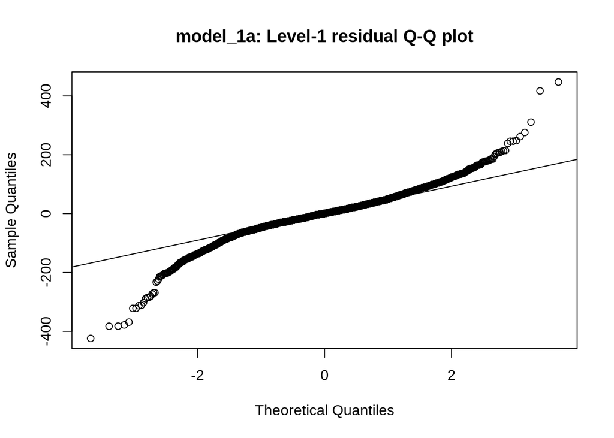

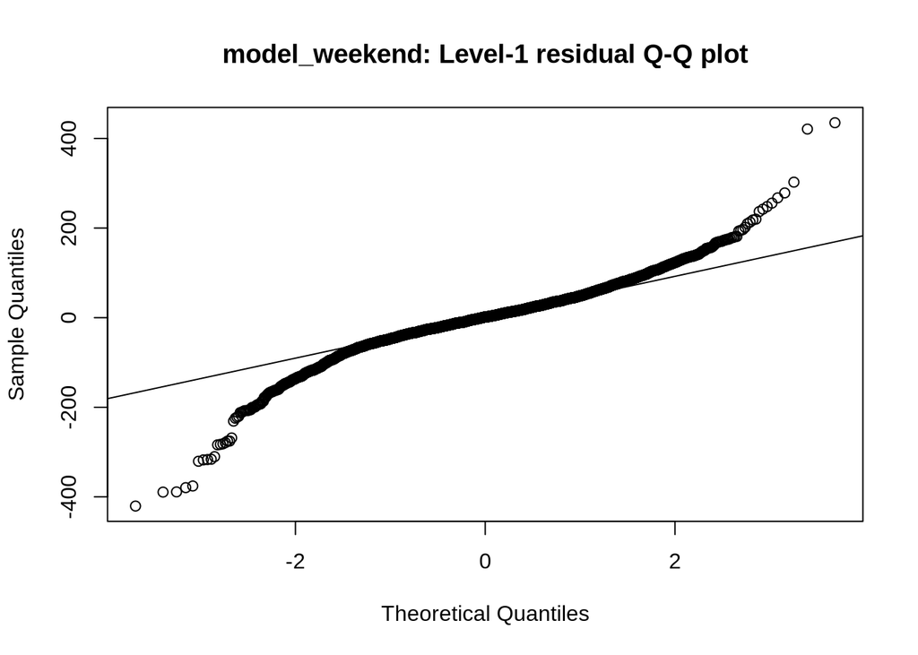

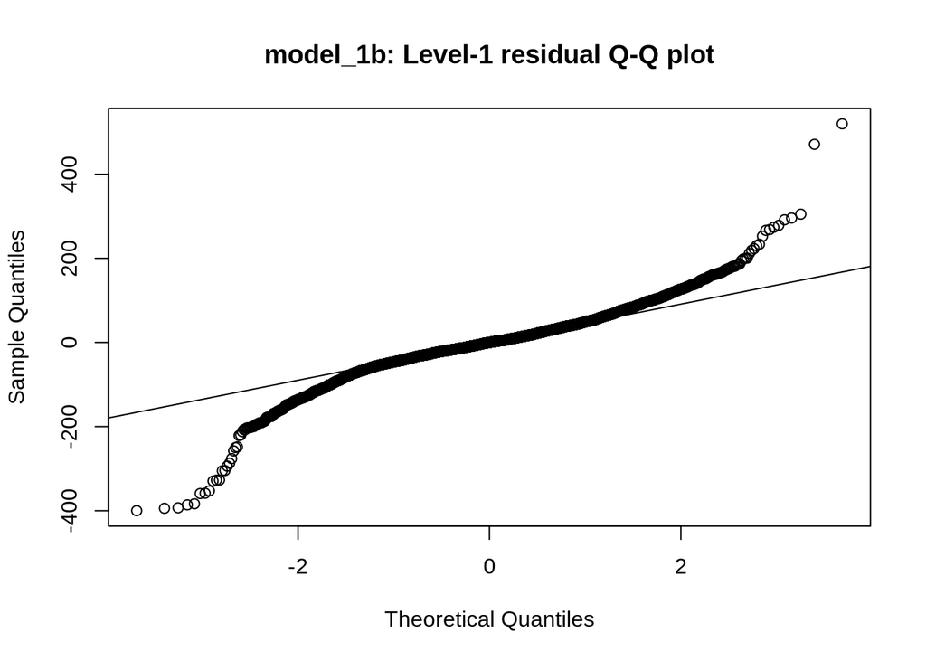

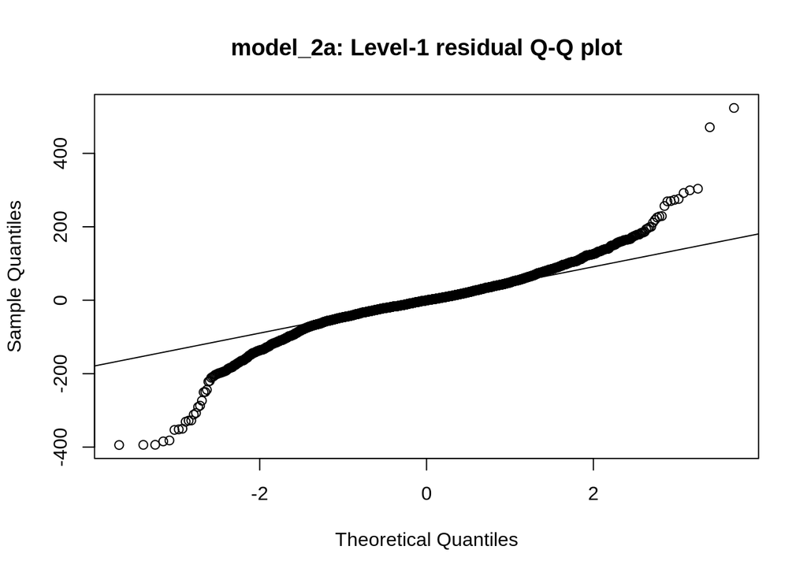

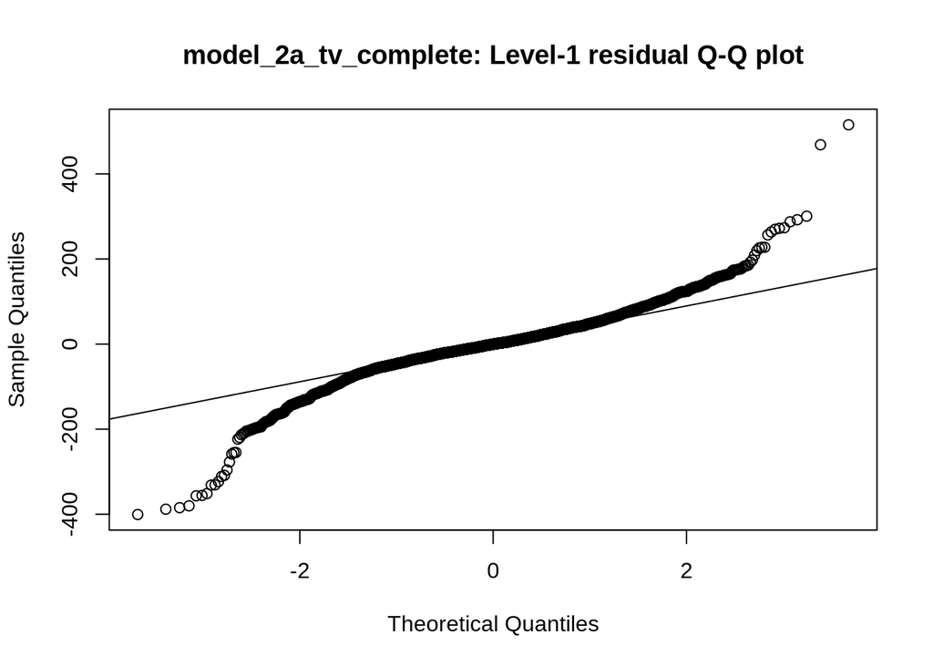

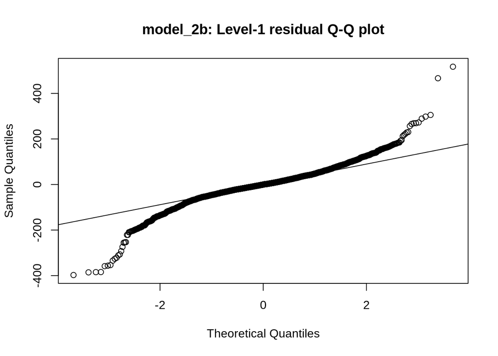

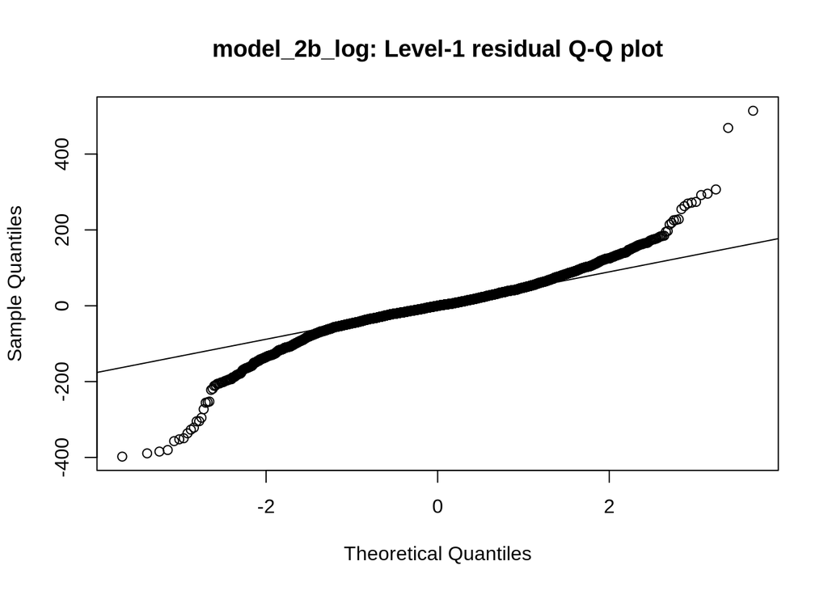